# Problem Set 3

Author

Regan Baros

Published

October 31, 2026

**GitHub repo:** https://github.com/rbaros001/ec522_ps3_baros

## Time and Tsibbles

### U.S. Census Bureau’s Monthly Retail Trade and Food Services

#### U.S. Census Bureau’s Monthly Retail Trade and Food Service Table

| observation_date | series_id | sales | Month |
| --- | --- | --- | --- |
| 1992-01-01 | RSAFS | 159177 | 1992 Jan |
| 1992-02-01 | RSAFS | 159189 | 1992 Feb |
| 1992-03-01 | RSAFS | 158647 | 1992 Mar |
| 1992-04-01 | RSAFS | 159921 | 1992 Apr |
| 1992-05-01 | RSAFS | 160471 | 1992 May |
| 1992-06-01 | RSAFS | 161205 | 1992 Jun |
| 1992-07-01 | RSAFS | 162855 | 1992 Jul |
| 1992-08-01 | RSAFS | 162412 | 1992 Aug |
| 1992-09-01 | RSAFS | 164361 | 1992 Sep |
| 1992-10-01 | RSAFS | 166063 | 1992 Oct |
| 1992-11-01 | RSAFS | 166124 | 1992 Nov |
| 1992-12-01 | RSAFS | 167691 | 1992 Dec |
| 1993-01-01 | RSAFS | 169500 | 1993 Jan |
| 1993-02-01 | RSAFS | 168840 | 1993 Feb |
| 1993-03-01 | RSAFS | 167682 | 1993 Mar |
| 1993-04-01 | RSAFS | 172102 | 1993 Apr |
| 1993-05-01 | RSAFS | 172960 | 1993 May |
| 1993-06-01 | RSAFS | 173018 | 1993 Jun |
| 1993-07-01 | RSAFS | 175822 | 1993 Jul |
| 1993-08-01 | RSAFS | 175233 | 1993 Aug |
| 1993-09-01 | RSAFS | 176608 | 1993 Sep |
| 1993-10-01 | RSAFS | 177588 | 1993 Oct |
| 1993-11-01 | RSAFS | 179758 | 1993 Nov |
| 1993-12-01 | RSAFS | 181077 | 1993 Dec |
| 1994-01-01 | RSAFS | 179615 | 1994 Jan |
| 1994-02-01 | RSAFS | 183101 | 1994 Feb |
| 1994-03-01 | RSAFS | 186721 | 1994 Mar |
| 1994-04-01 | RSAFS | 186423 | 1994 Apr |
| 1994-05-01 | RSAFS | 185616 | 1994 May |
| 1994-06-01 | RSAFS | 187800 | 1994 Jun |

[output cut: 804 more lines]

#### U.S. Census Bureau’s Monthly Retail Trade and Food Service Plot

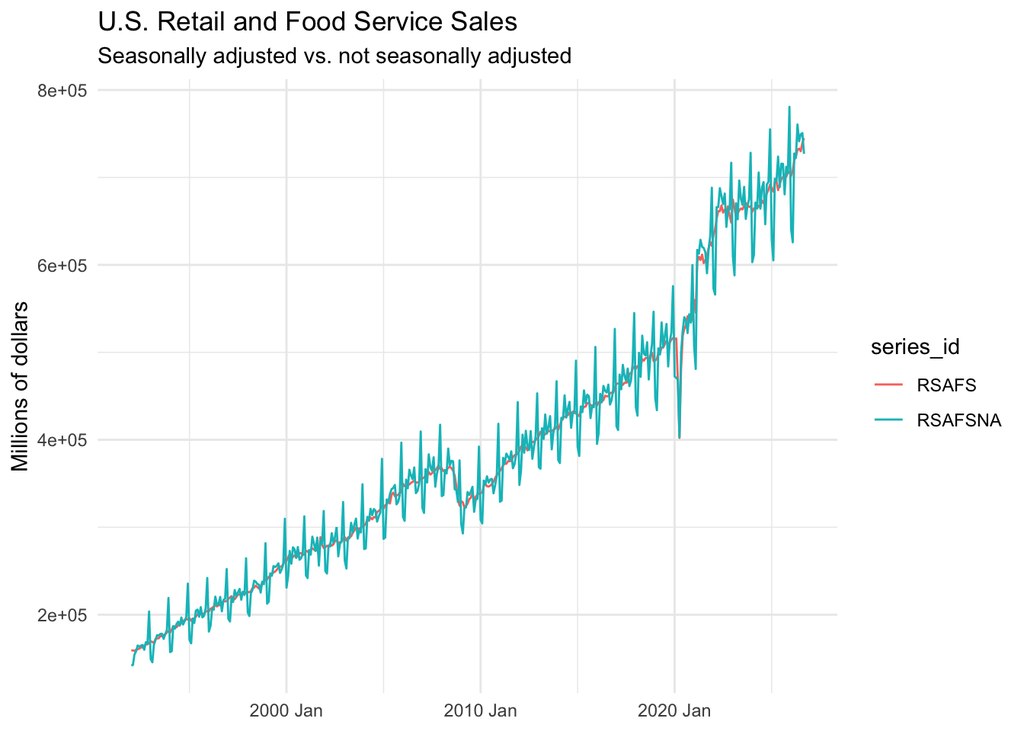

In the series that is not seasonally adjusted, RSAFSNA, there are major spikes and drops that follow a general pattern year to year. The seasonally adjusted series removes these reaccuring patters to show the true underlying trend.

Over the long run, the two series follow the same path. The seasonally adjusted data has dips around 2008 and 2020 which reflect the great recession and the pandemic. The unadjusted data also follows this trend, but also shows the monthly swings.

### Canadian Gas Production Volume

The Canadian gas production time series consist of monthly natural gas production in Canada as a measure of billions of cubic meters from January 1960 to February 2005. The data set uses a monthly index (denoted as Month) with the gas production variable called Volume. There are no key variables in this data set because there is only one series.

#### Recent Canadian Gas Production from January 1990 to February 2005 Table

June has the lowest average production and December has the highest.

| Month | Volume | year | month | quarter |
| --- | --- | --- | --- | --- |
| 1990 Jan | 12.5080 | 1990 | Jan | 1 |
| 1990 Feb | 11.1611 | 1990 | Feb | 1 |
| 1990 Mar | 11.5871 | 1990 | Mar | 1 |
| 1990 Apr | 11.1003 | 1990 | Apr | 2 |
| 1990 May | 10.9631 | 1990 | May | 2 |
| 1990 Jun | 10.1271 | 1990 | Jun | 2 |
| 1990 Jul | 10.5513 | 1990 | Jul | 3 |
| 1990 Aug | 10.4668 | 1990 | Aug | 3 |
| 1990 Sep | 10.2710 | 1990 | Sep | 3 |
| 1990 Oct | 11.9920 | 1990 | Oct | 4 |
| 1990 Nov | 12.1350 | 1990 | Nov | 4 |
| 1990 Dec | 13.4248 | 1990 | Dec | 4 |
| 1991 Jan | 13.2500 | 1991 | Jan | 1 |
| 1991 Feb | 11.3410 | 1991 | Feb | 1 |
| 1991 Mar | 12.4856 | 1991 | Mar | 1 |
| 1991 Apr | 11.9009 | 1991 | Apr | 2 |
| 1991 May | 11.3834 | 1991 | May | 2 |
| 1991 Jun | 10.8104 | 1991 | Jun | 2 |
| 1991 Jul | 10.6474 | 1991 | Jul | 3 |
| 1991 Aug | 10.5999 | 1991 | Aug | 3 |
| 1991 Sep | 10.7973 | 1991 | Sep | 3 |
| 1991 Oct | 12.4401 | 1991 | Oct | 4 |
| 1991 Nov | 12.9722 | 1991 | Nov | 4 |
| 1991 Dec | 13.8099 | 1991 | Dec | 4 |
| 1992 Jan | 13.2705 | 1992 | Jan | 1 |
| 1992 Feb | 12.7163 | 1992 | Feb | 1 |
| 1992 Mar | 13.1994 | 1992 | Mar | 1 |
| 1992 Apr | 12.7235 | 1992 | Apr | 2 |
| 1992 May | 12.5501 | 1992 | May | 2 |
| 1992 Jun | 11.5166 | 1992 | Jun | 2 |

[output cut: 152 more lines]

#### Quarterly Canadian Gas Production Table

| Quarter | Volume |
| --- | --- |
| 1960 Q1 | 4.1387 |
| 1960 Q2 | 3.2973 |
| 1960 Q3 | 2.9744 |
| 1960 Q4 | 4.2577 |
| 1961 Q1 | 5.0055 |
| 1961 Q2 | 4.1670 |
| 1961 Q3 | 3.8696 |
| 1961 Q4 | 5.5749 |
| 1962 Q1 | 7.1500 |
| 1962 Q2 | 6.0508 |
| 1962 Q3 | 6.1131 |
| 1962 Q4 | 7.6201 |
| 1963 Q1 | 8.5465 |
| 1963 Q2 | 7.2944 |
| 1963 Q3 | 6.9856 |
| 1963 Q4 | 8.8638 |
| 1964 Q1 | 9.9658 |
| 1964 Q2 | 8.5862 |
| 1964 Q3 | 8.2916 |
| 1964 Q4 | 10.4700 |
| 1965 Q1 | 11.1357 |
| 1965 Q2 | 9.6032 |
| 1965 Q3 | 9.0195 |
| 1965 Q4 | 11.1838 |
| 1966 Q1 | 11.9600 |
| 1966 Q2 | 10.2971 |
| 1966 Q3 | 9.4926 |
| 1966 Q4 | 12.2687 |
| 1967 Q1 | 12.7844 |
| 1967 Q2 | 11.3368 |

[output cut: 150 more lines]

#### Quarterly Canadian Gas Production Plot

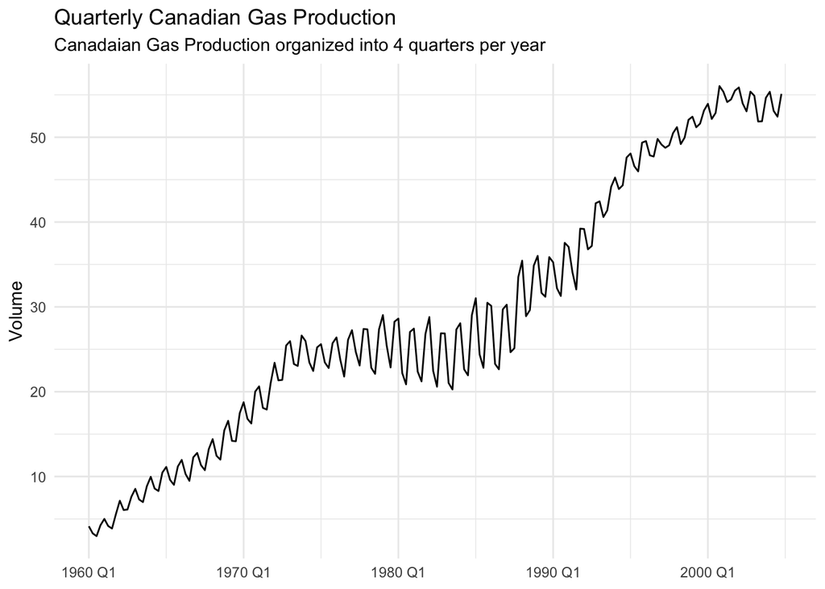

When finding the quarterly Canadian gas production, you will use the sum() function for monthly values because we are looking for cumulative totals of volume rather than a snapshot of the values which mean would give us. The quarterly series does appear to also be seasonal across quarters.

#### Canadian Gas Production Table

| Month | Volume |
| --- | --- |
| 1960 Jan | 1.4306 |
| 1960 Feb | 1.3059 |
| 1960 Mar | 1.4022 |
| 1960 Apr | 1.1699 |
| 1960 May | 1.1161 |
| 1960 Jun | 1.0113 |
| 1960 Jul | 0.9660 |
| 1960 Aug | 0.9773 |
| 1960 Sep | 1.0311 |
| 1960 Oct | 1.2521 |
| 1960 Nov | 1.4419 |
| 1960 Dec | 1.5637 |
| 1961 Jan | 1.7450 |
| 1961 Feb | 1.5835 |
| 1961 Mar | 1.6770 |
| 1961 Apr | 1.5155 |
| 1961 May | 1.4051 |
| 1961 Jun | 1.2464 |
| 1961 Jul | 1.2238 |
| 1961 Aug | 1.2917 |
| 1961 Sep | 1.3541 |
| 1961 Oct | 1.5552 |
| 1961 Nov | 1.7648 |
| 1961 Dec | 2.2549 |
| 1962 Jan | 2.4164 |
| 1962 Feb | 2.3484 |
| 1962 Mar | 2.3852 |
| 1962 Apr | 2.0651 |
| 1962 May | 2.0594 |
| 1962 Jun | 1.9263 |

[output cut: 512 more lines]

#### Canadian Gas Production Plot

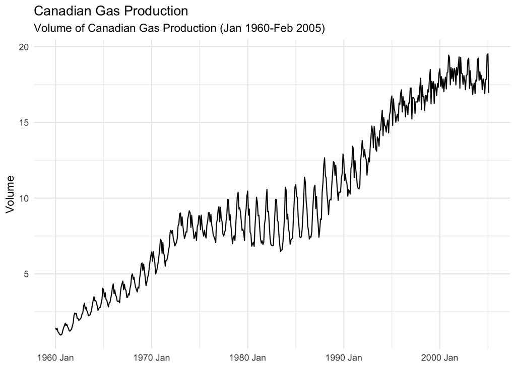

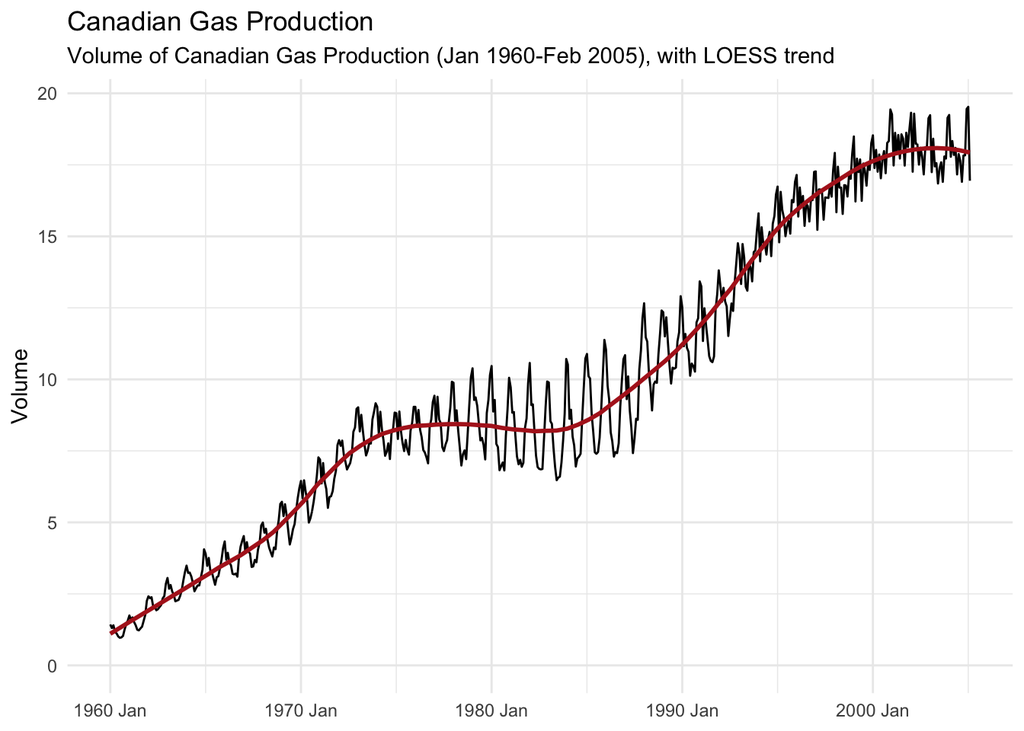

A loess curve was added to the time series to show underlying trend. On the y-axis, 0 added as well as breaks from 0 to 20 jumping by 5s.

## Transformations

### U.S. Census Bureau’s Monthly Retail Trade and Food Services

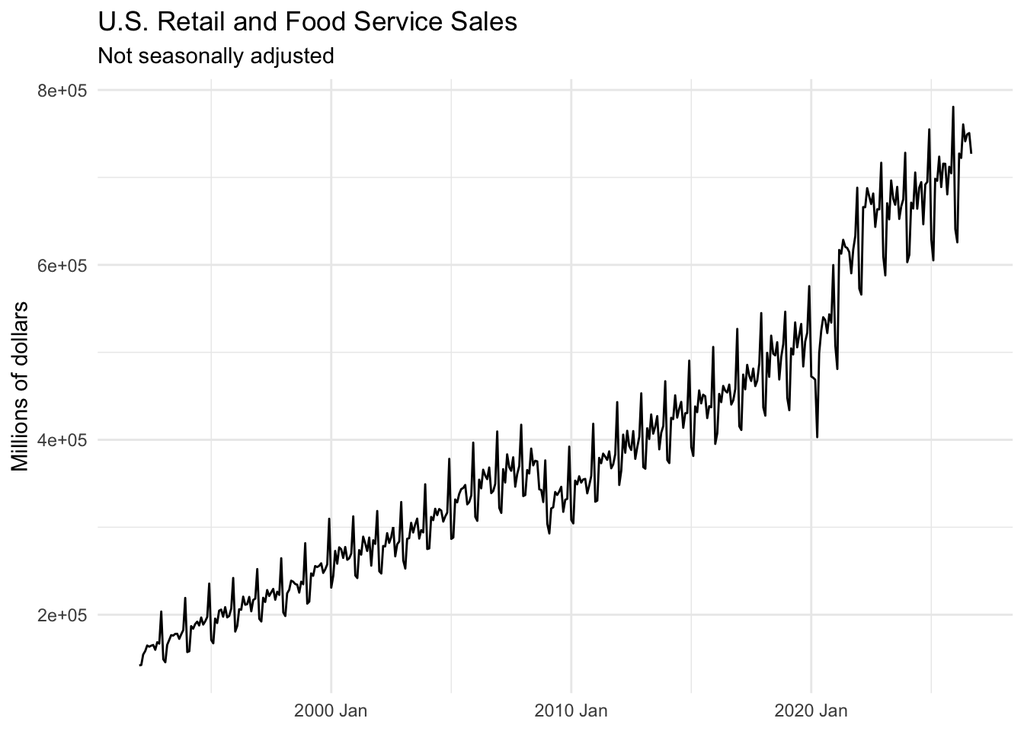

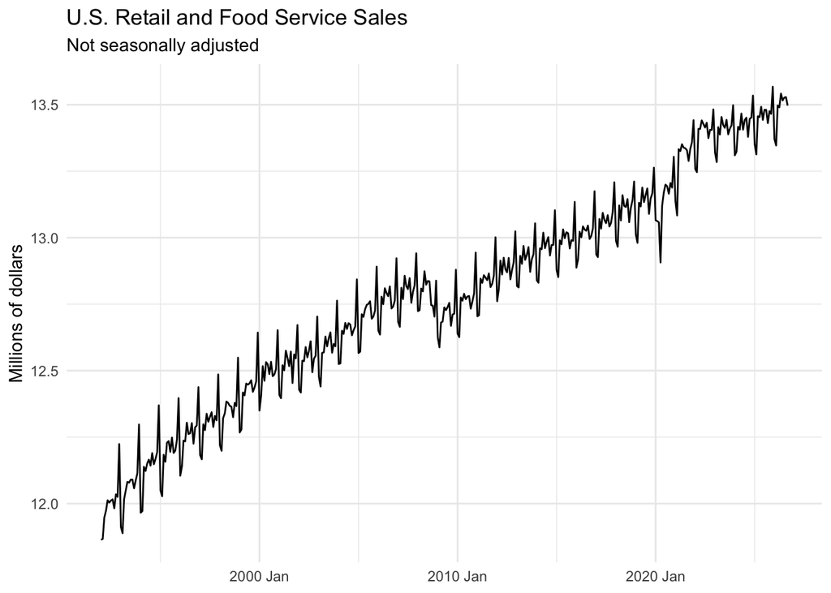

This series has a weaker case for logging compared to Canadian gas production. The underlying trend does not have a large significant difference between the logged and the un-logged version. While using the logged version of non-seasonally adjusted sales shows the clear linear upward trend in terms of absolute change, the un-logged sales also show this same pattern. While it does have a weaker case, the logged version of sales can still give you more information about absolute change that is not as clear in the un-logged version.

#### Seasonally Adjusted and Non-Seasonally Adjusted Growth Rates Plot

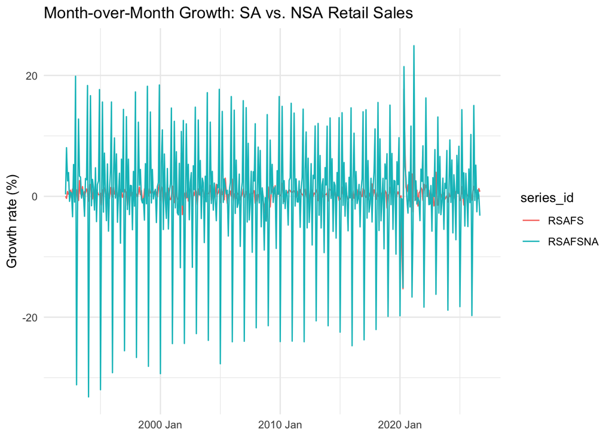

The non-seasonally adjusted series shows significantly more noise. The RSAFSNA series has much larger seasonal swings indicating more noise. The seasonally adjusted data removes these large swings to show true changes.

### Canadian Gas Production

The seasonal swings seem to change with time. There is a time period around 1980 to about 1990 where there are large seasonal swings. After this period, there is still growth, and the swings are still present but not nearly as large.

#### Logged Canadian Gas Production

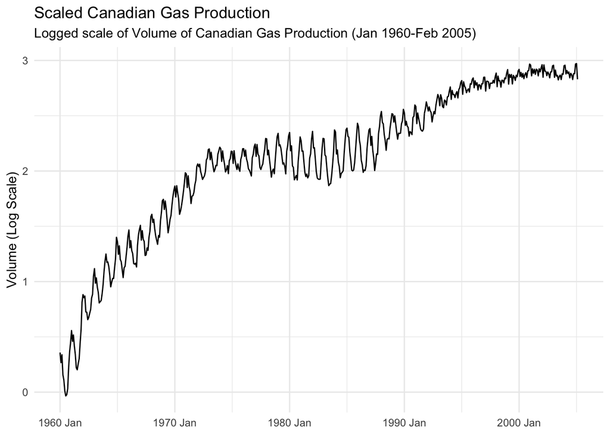

The log transformation taken of the Canadian gas production time series plot to show a true scale of gas production and reveal how growth has slowed over time.

Taking the natural log of the can_gas time series is a good idea because without this, it appears that growth is trending upwards at the same rate. The log shows absolute change, so the logged version shows a clearer picture of how gas production has actually changed over time. This transformation shows the significant growth from the 1960s to around 1975. After this point production still grows but significantly flattens out.

#### Month-Over-Month Growth Rate Plot

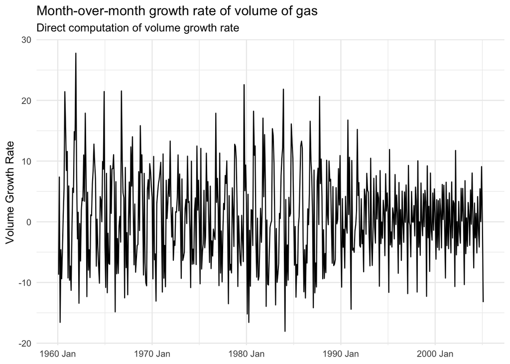

#### Month-Over-Month Growth Gap Plot

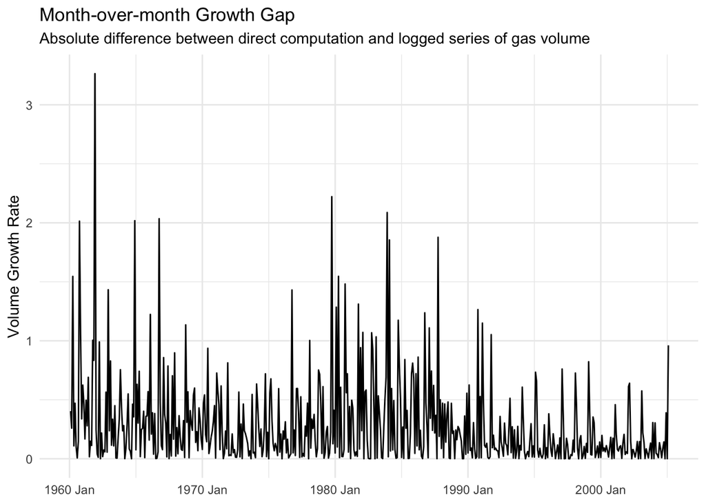

In this case, it seems as though the logged difference has some error, but there aren’t any significantly large differences shown in the graph.

## Seasonality

### U.S. Census Bureau’s Monthly Retail Trade and Food Services

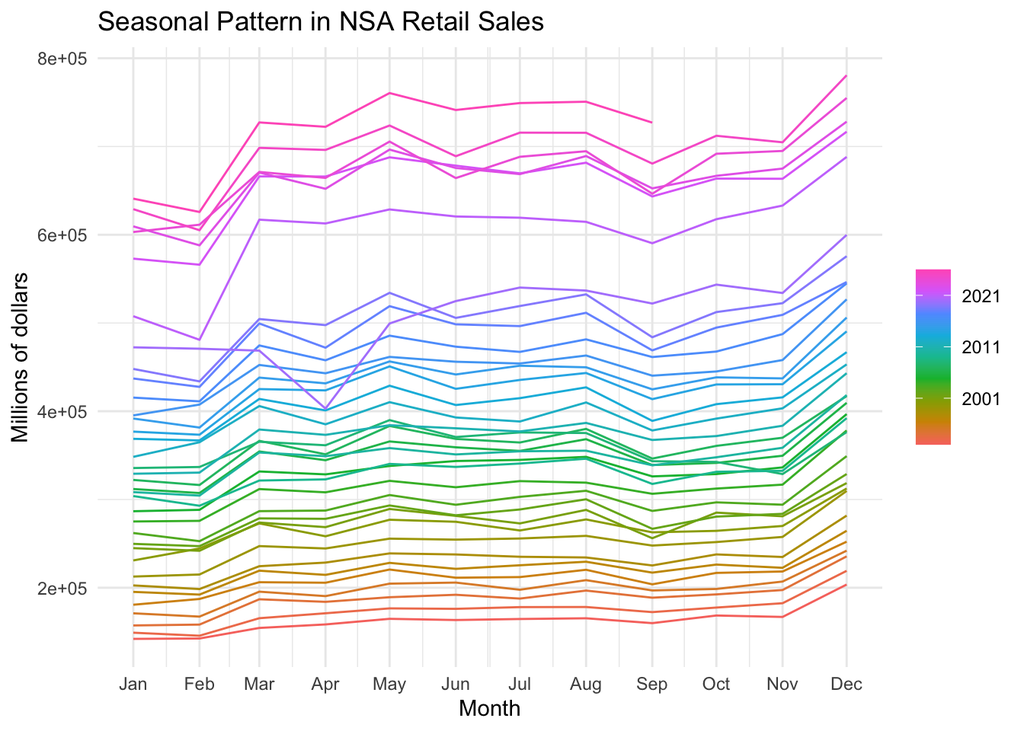

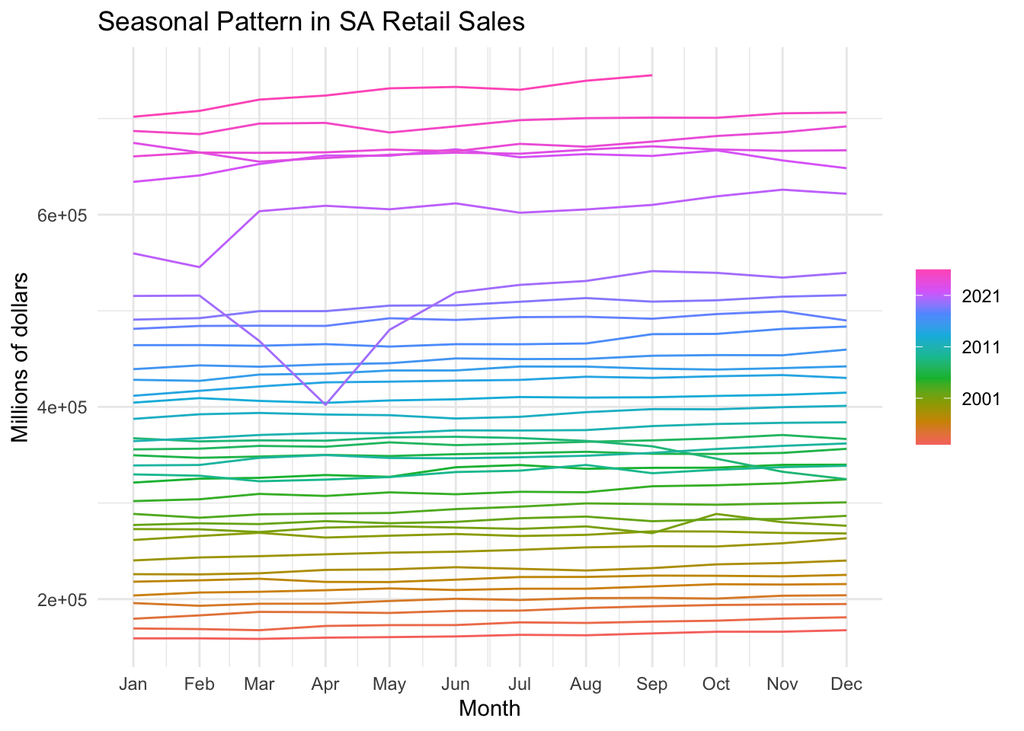

#### X-13ARIMA-SEATS DECOMPOSITION

The seasonal factor seems to be highest in December, which tracts with the holidays being around this time. Sales at this time are roughly 10% to 20% above trend during this month. The seasonal swings appear to get somewhat smaller over time but are still present.

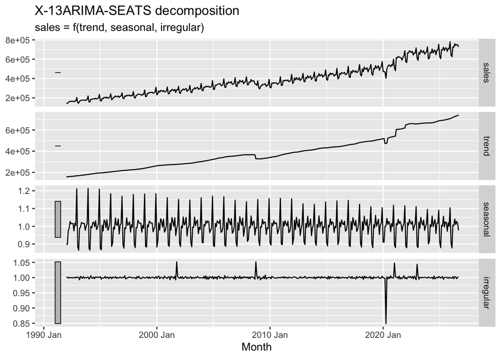

| series_id | .model | Month | sales | trend | seasonal | irregular | season_adjust |
| --- | --- | --- | --- | --- | --- | --- | --- |
| RSAFSNA | x13 | 1992 Jan | 142051 | 157607.1 | 0.8987146 | 1.0008974 | 158060.2 |
| RSAFSNA | x13 | 1992 Feb | 142498 | 158337.9 | 0.8981025 | 1.0011297 | 158665.6 |
| RSAFSNA | x13 | 1992 Mar | 154439 | 159022.7 | 0.9740604 | 0.9982276 | 158551.8 |
| RSAFSNA | x13 | 1992 Apr | 158430 | 159774.8 | 0.9915945 | 1.0006338 | 159773.0 |
| RSAFSNA | x13 | 1992 May | 164788 | 160566.2 | 1.0273818 | 0.9995339 | 160396.1 |
| RSAFSNA | x13 | 1992 Jun | 163417 | 161394.9 | 1.0141469 | 0.9994019 | 161137.4 |
| RSAFSNA | x13 | 1992 Jul | 164575 | 162283.5 | 1.0148816 | 1.0001644 | 162161.8 |
| RSAFSNA | x13 | 1992 Aug | 165387 | 163228.4 | 1.0158998 | 0.9988964 | 162798.5 |
| RSAFSNA | x13 | 1992 Sep | 159892 | 164264.1 | 0.9738335 | 0.9997524 | 164188.2 |
| RSAFSNA | x13 | 1992 Oct | 168529 | 165319.5 | 1.0173492 | 1.0012676 | 165655.0 |
| RSAFSNA | x13 | 1992 Nov | 166918 | 166340.1 | 1.0039064 | 0.9988320 | 166268.5 |
| RSAFSNA | x13 | 1992 Dec | 203616 | 167326.4 | 1.2109852 | 1.0021560 | 168140.8 |
| RSAFSNA | x13 | 1993 Jan | 149066 | 168167.2 | 0.8831426 | 1.0008636 | 168790.4 |
| RSAFSNA | x13 | 1993 Feb | 145607 | 168852.9 | 0.8653336 | 1.0003213 | 168266.9 |
| RSAFSNA | x13 | 1993 Mar | 165467 | 169757.8 | 0.9884908 | 0.9928610 | 167393.6 |
| RSAFSNA | x13 | 1993 Apr | 171075 | 171060.1 | 0.9952492 | 1.0038047 | 171891.6 |
| RSAFSNA | x13 | 1993 May | 176619 | 172312.5 | 1.0213200 | 1.0011193 | 172932.1 |
| RSAFSNA | x13 | 1993 Jun | 176095 | 173430.8 | 1.0180675 | 0.9976261 | 172969.9 |
| RSAFSNA | x13 | 1993 Jul | 178060 | 174572.3 | 1.0151819 | 1.0032032 | 175397.1 |
| RSAFSNA | x13 | 1993 Aug | 178176 | 175631.5 | 1.0165100 | 0.9982210 | 175282.1 |
| RSAFSNA | x13 | 1993 Sep | 172381 | 176708.4 | 0.9773123 | 1.0000358 | 176382.7 |
| RSAFSNA | x13 | 1993 Oct | 177545 | 177902.2 | 1.0000204 | 0.9989005 | 177541.4 |
| RSAFSNA | x13 | 1993 Nov | 182451 | 179157.7 | 1.0158815 | 1.0007684 | 179598.7 |
| RSAFSNA | x13 | 1993 Dec | 219162 | 180317.8 | 1.2126552 | 1.0020646 | 180729.0 |
| RSAFSNA | x13 | 1994 Jan | 157262 | 181469.3 | 0.8753621 | 0.9954242 | 179653.7 |
| RSAFSNA | x13 | 1994 Feb | 158247 | 182958.6 | 0.8659968 | 0.9989674 | 182733.9 |
| RSAFSNA | x13 | 1994 Mar | 186925 | 184467.6 | 0.9995702 | 1.0063683 | 187005.4 |
| RSAFSNA | x13 | 1994 Apr | 184025 | 185529.7 | 0.9912890 | 0.9991964 | 185642.1 |
| RSAFSNA | x13 | 1994 May | 189261 | 186504.1 | 1.0204816 | 0.9973449 | 185462.4 |
| RSAFSNA | x13 | 1994 Jun | 192034 | 187662.0 | 1.0230479 | 1.0017354 | 187707.7 |

[output cut: 387 more lines]

#### Comparison of Official Seasonally Adjusted Series

| Month | mine | census | pct_diff |
| --- | --- | --- | --- |
| 1992 Jan | 158060.2 | 159177 | -0.7040912 |
| 1992 Feb | 158665.6 | 159189 | -0.3293096 |
| 1992 Mar | 158551.8 | 158647 | -0.0600415 |
| 1992 Apr | 159773.0 | 159921 | -0.0926099 |
| 1992 May | 160396.1 | 160471 | -0.0467114 |
| 1992 Jun | 161137.4 | 161205 | -0.0419434 |
| 1992 Jul | 162161.8 | 162855 | -0.4265842 |
| 1992 Aug | 162798.5 | 162412 | 0.2377144 |
| 1992 Sep | 164188.2 | 164361 | -0.1051705 |
| 1992 Oct | 165655.0 | 166063 | -0.2459778 |
| 1992 Nov | 166268.5 | 166124 | 0.0869365 |
| 1992 Dec | 168140.8 | 167691 | 0.2678606 |
| 1993 Jan | 168790.4 | 169500 | -0.4195194 |
| 1993 Feb | 168266.9 | 168840 | -0.3400177 |
| 1993 Mar | 167393.6 | 167682 | -0.1721558 |
| 1993 Apr | 171891.6 | 172102 | -0.1223124 |
| 1993 May | 172932.1 | 172960 | -0.0161367 |
| 1993 Jun | 172969.9 | 173018 | -0.0278273 |
| 1993 Jul | 175397.1 | 175822 | -0.2419368 |
| 1993 Aug | 175282.1 | 175233 | 0.0280125 |
| 1993 Sep | 176382.7 | 176608 | -0.1276396 |
| 1993 Oct | 177541.4 | 177588 | -0.0262531 |
| 1993 Nov | 179598.7 | 179758 | -0.0886539 |
| 1993 Dec | 180729.0 | 181077 | -0.1923521 |
| 1994 Jan | 179653.7 | 179615 | 0.0215197 |
| 1994 Feb | 182733.9 | 183101 | -0.2006693 |
| 1994 Mar | 187005.4 | 186721 | 0.1521805 |
| 1994 Apr | 185642.1 | 186423 | -0.4197488 |
| 1994 May | 185462.4 | 185616 | -0.0827681 |
| 1994 Jun | 187707.7 | 187800 | -0.0491456 |

[output cut: 387 more lines]

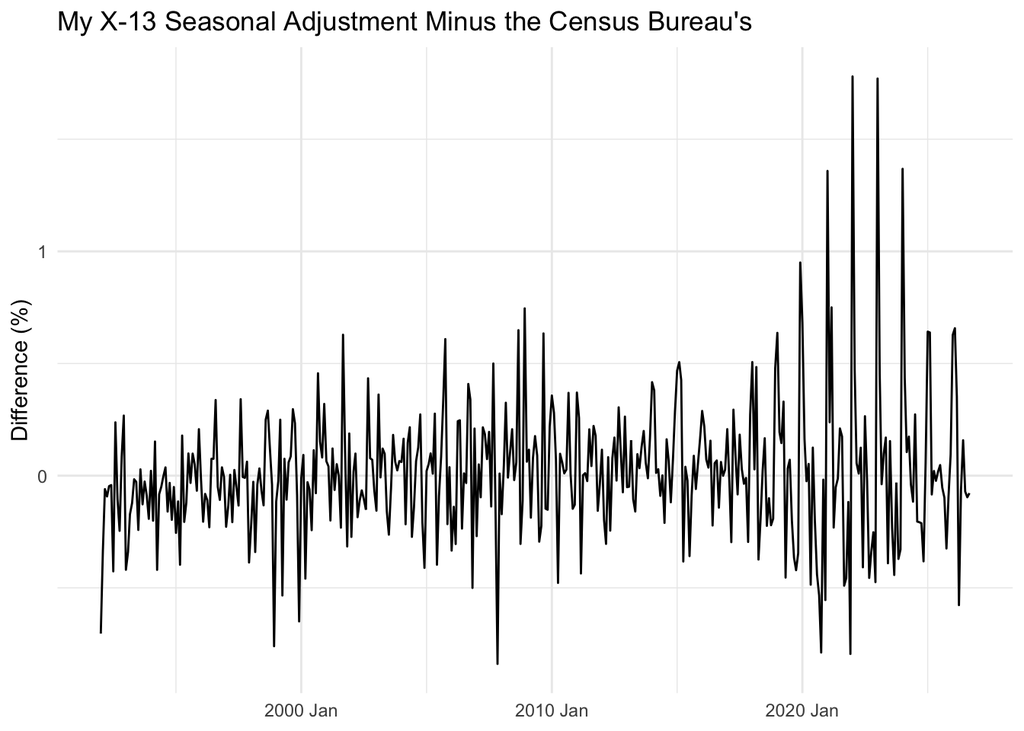

The adjustment matches closely with only 4 months after 2020 that go over a 1% difference. The largest differences seem to be skewed left skewed with larger differences around 2020 and after. The differences do not follow any sort of pattern.

### Canadian Gas Production

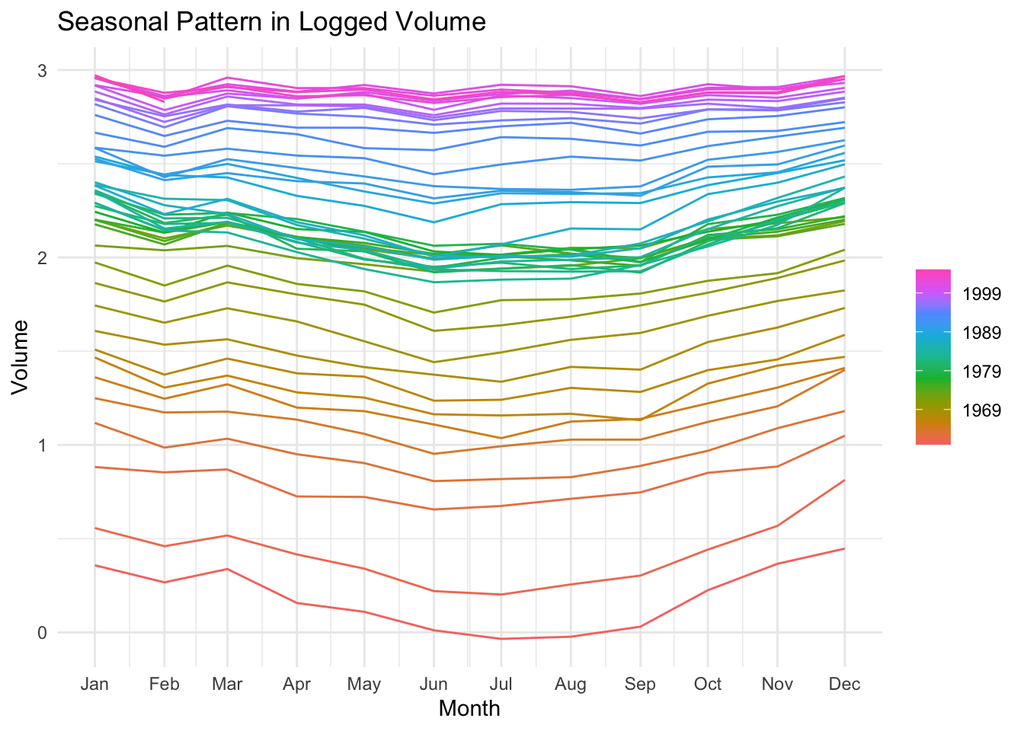

The months that tend to be higher in colder months, October to March, and lower in warmer months, April to September. This makes sense because people may be using extra gas to heat their homes in colder weather.

#### Subbseries Plot

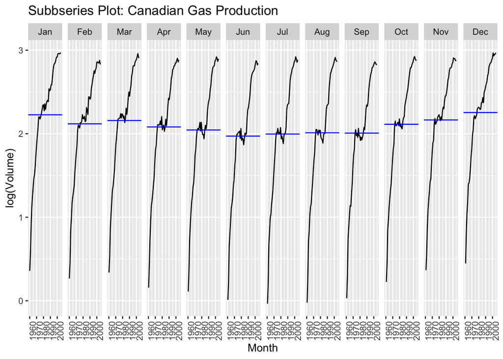

#### Simple Model of a Linear Trend and Seasonal Dummy

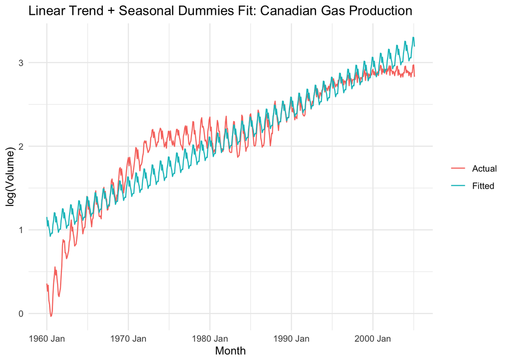

The linear model tracts the actual series somewhat accurately from 1980 to about 2000 with some differences in seasonal swing magnitude. The linear model misses significantly from 1960 to 1980 and over forecasts after 2000.

| term | estimate | std.error | statistic | p.value |
| --- | --- | --- | --- | --- |
| (Intercept) | 1.150 | 0.041 | 27.761 | 0.000 |
| trend() | 0.004 | 0.000 | 57.692 | 0.000 |
| season()year2 | -0.112 | 0.052 | -2.144 | 0.032 |
| season()year3 | -0.052 | 0.053 | -0.996 | 0.320 |
| season()year4 | -0.133 | 0.053 | -2.537 | 0.011 |
| season()year5 | -0.174 | 0.053 | -3.305 | 0.001 |
| season()year6 | -0.251 | 0.053 | -4.777 | 0.000 |
| season()year7 | -0.230 | 0.053 | -4.374 | 0.000 |
| season()year8 | -0.219 | 0.053 | -4.170 | 0.000 |
| season()year9 | -0.227 | 0.053 | -4.325 | 0.000 |
| season()year10 | -0.125 | 0.053 | -2.383 | 0.018 |
| season()year11 | -0.078 | 0.053 | -1.480 | 0.140 |
| season()year12 | 0.007 | 0.053 | 0.137 | 0.891 |

The estimated average rate of production is about -0.133 lower than that of January. The month with the largest seasonal effect is year 6 with a -4.777 t statistic.

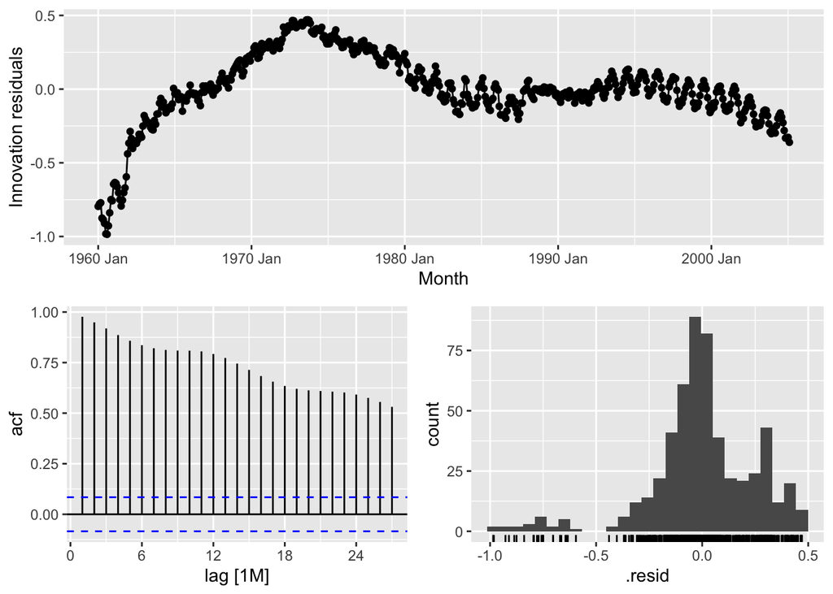

```
# A tibble: 1 × 3
  .model                                lb_stat lb_pvalue
  <chr>                                   <dbl>     <dbl>
1 TSLM(log_volume ~ trend() + season())   7774.         0
```

There is visible structure to the residuals therefore, they do not look like white noise. The Ljung box test concludes that we would reject the null hypothesis at the 5% significance level.

## Forecast Evaluation

### Canadian Gas Production

#### Expanding Window Forecast

| .id | .model | Month | Volume | .mean |
| --- | --- | --- | --- | --- |
| 1 | snaive | 1980 Jan | N(10, 0.3) | 10.38610 |
| 1 | tslm | 1980 Jan | t(N(2.7, 0.042)) | 15.10228 |
| 2 | snaive | 1980 Feb | N(9.3, 0.3) | 9.27970 |
| 2 | tslm | 1980 Feb | t(N(2.6, 0.042)) | 13.60303 |
| 3 | snaive | 1980 Mar | N(9.4, 0.3) | 9.36950 |
| 3 | tslm | 1980 Mar | t(N(2.6, 0.043)) | 14.41126 |
| 4 | snaive | 1980 Apr | N(9.1, 0.3) | 9.07040 |
| 4 | tslm | 1980 Apr | t(N(2.6, 0.043)) | 13.14892 |
| 5 | snaive | 1980 May | N(8.5, 0.31) | 8.47790 |
| 5 | tslm | 1980 May | t(N(2.5, 0.044)) | 12.46459 |
| 6 | snaive | 1980 Jun | N(7.9, 0.31) | 7.86640 |
| 6 | tslm | 1980 Jun | t(N(2.4, 0.045)) | 11.38336 |
| 7 | snaive | 1980 Jul | N(8, 0.31) | 7.95030 |
| 7 | tslm | 1980 Jul | t(N(2.4, 0.046)) | 11.42554 |
| 8 | snaive | 1980 Aug | N(7.7, 0.32) | 7.70680 |
| 8 | tslm | 1980 Aug | t(N(2.4, 0.047)) | 11.68127 |
| 9 | snaive | 1980 Sep | N(7.2, 0.32) | 7.20120 |
| 9 | tslm | 1980 Sep | t(N(2.4, 0.047)) | 11.66969 |
| 10 | snaive | 1980 Oct | N(8.8, 0.31) | 8.82760 |
| 10 | tslm | 1980 Oct | t(N(2.5, 0.048)) | 13.06748 |
| 11 | snaive | 1980 Nov | N(9.3, 0.32) | 9.27970 |
| 11 | tslm | 1980 Nov | t(N(2.6, 0.049)) | 13.93002 |
| 12 | snaive | 1980 Dec | N(10, 0.31) | 10.14720 |
| 12 | tslm | 1980 Dec | t(N(2.7, 0.049)) | 15.34773 |
| 13 | snaive | 1981 Jan | N(10, 0.31) | 10.46670 |
| 13 | tslm | 1981 Jan | t(N(2.7, 0.05)) | 15.35495 |
| 14 | snaive | 1981 Feb | N(8.9, 0.31) | 8.87720 |
| 14 | tslm | 1981 Feb | t(N(2.6, 0.05)) | 13.77806 |
| 15 | snaive | 1981 Mar | N(9.3, 0.31) | 9.28000 |
| 15 | tslm | 1981 Mar | t(N(2.7, 0.051)) | 14.58514 |

[output cut: 576 more lines]

#### Diebold-Mariano Test

| Month | snaive | tslm |
| --- | --- | --- |
| 1980 Jan | 0.0806 | -4.6355837 |
| 1980 Feb | -0.4025 | -4.7258340 |
| 1980 Mar | -0.0895 | -5.1312638 |
| 1980 Apr | -1.3282 | -5.4067177 |
| 1980 May | -0.8439 | -4.8305946 |
| 1980 Jun | -1.0423 | -4.5592554 |
| 1980 Jul | -0.9903 | -4.4655380 |
| 1980 Aug | -0.6142 | -4.5886725 |
| 1980 Sep | -0.3864 | -4.8548948 |
| 1980 Oct | -0.7715 | -5.0113827 |
| 1980 Nov | -0.3412 | -4.9915194 |
| 1980 Dec | -0.0923 | -5.2928250 |
| 1981 Jan | -0.7460 | -5.6342457 |
| 1981 Feb | -0.0432 | -4.9440603 |
| 1981 Mar | -0.3929 | -5.6980392 |
| 1981 Apr | 0.2857 | -5.2158946 |
| 1981 May | -0.3250 | -5.2729846 |
| 1981 Jun | 0.2071 | -4.4419019 |
| 1981 Jul | 0.2271 | -4.3399355 |
| 1981 Aug | -0.1486 | -4.8419873 |
| 1981 Sep | 0.2698 | -4.6646171 |
| 1981 Oct | 0.2384 | -4.8999801 |
| 1981 Nov | -0.3021 | -5.4584195 |
| 1981 Dec | -0.1783 | -5.6614201 |
| 1982 Jan | 0.8530 | -4.9113019 |
| 1982 Feb | 0.2665 | -4.8134976 |
| 1982 Mar | 0.2403 | -5.5708991 |
| 1982 Apr | 0.1610 | -5.1572389 |
| 1982 May | 0.0273 | -5.3201106 |
| 1982 Jun | -0.0967 | -4.6344902 |

[output cut: 272 more lines]

```
    Diebold-Mariano Test

data:  errs$snaiveerrs$tslm
DM = -31.278, Forecast horizon = 1, Loss function power = 1, p-value <
2.2e-16
alternative hypothesis: two.sided
```

#### Rolling Window Forecast

| .id | .model | Month | Volume | .mean |
| --- | --- | --- | --- | --- |
| 1 | snaive | 1980 Jan | N(10, 0.3) | 10.386100 |
| 1 | tslm | 1980 Jan | t(N(2.7, 0.042)) | 15.102284 |
| 2 | snaive | 1980 Feb | N(9.3, 0.3) | 9.279700 |
| 2 | tslm | 1980 Feb | t(N(2.6, 0.042)) | 13.529609 |
| 3 | snaive | 1980 Mar | N(9.4, 0.3) | 9.369500 |
| 3 | tslm | 1980 Mar | t(N(2.6, 0.042)) | 14.256501 |
| 4 | snaive | 1980 Apr | N(9.1, 0.3) | 9.070400 |
| 4 | tslm | 1980 Apr | t(N(2.5, 0.042)) | 12.937603 |
| 5 | snaive | 1980 May | N(8.5, 0.31) | 8.477900 |
| 5 | tslm | 1980 May | t(N(2.5, 0.042)) | 12.178000 |
| 6 | snaive | 1980 Jun | N(7.9, 0.31) | 7.866400 |
| 6 | tslm | 1980 Jun | t(N(2.4, 0.041)) | 11.041357 |
| 7 | snaive | 1980 Jul | N(8, 0.32) | 7.950300 |
| 7 | tslm | 1980 Jul | t(N(2.4, 0.041)) | 10.997865 |
| 8 | snaive | 1980 Aug | N(7.7, 0.32) | 7.706800 |
| 8 | tslm | 1980 Aug | t(N(2.4, 0.04)) | 11.146242 |
| 9 | snaive | 1980 Sep | N(7.2, 0.32) | 7.201200 |
| 9 | tslm | 1980 Sep | t(N(2.4, 0.039)) | 11.033347 |
| 10 | snaive | 1980 Oct | N(8.8, 0.32) | 8.827600 |
| 10 | tslm | 1980 Oct | t(N(2.5, 0.039)) | 12.249328 |
| 11 | snaive | 1980 Nov | N(9.3, 0.33) | 9.279700 |
| 11 | tslm | 1980 Nov | t(N(2.5, 0.038)) | 12.960532 |
| 12 | snaive | 1980 Dec | N(10, 0.33) | 10.147200 |
| 12 | tslm | 1980 Dec | t(N(2.6, 0.038)) | 14.187991 |
| 13 | snaive | 1981 Jan | N(10, 0.32) | 10.466700 |
| 13 | tslm | 1981 Jan | t(N(2.6, 0.037)) | 14.405366 |
| 14 | snaive | 1981 Feb | N(8.9, 0.32) | 8.877200 |
| 14 | tslm | 1981 Feb | t(N(2.5, 0.037)) | 12.847498 |
| 15 | snaive | 1981 Mar | N(9.3, 0.32) | 9.280000 |
| 15 | tslm | 1981 Mar | t(N(2.6, 0.036)) | 13.518806 |

[output cut: 576 more lines]

## Reflection

A method that could be used to adjust for these gaps is a exponential smoothing model that captures level, trend, and seasonal patterns. This type of model uses weighted averages of past observations which are constantly being updated as new observations arrive. This would make the changes with season more accurate.